# Analysis of Intraday Stock Prices

David Chuang

## Introduction

In the fast-paced world of financial markets, every second counts. The ability to predict and analyze stock price movements within a single trading day, known as intraday trading, can be the difference between profit and loss for traders and investors. This project aims to leverage the power of data science to delve into the intricacies of intraday stock price movements.

Our objective is to harness the potential of machine learning algorithms and statistical models to predict intraday stock price movements. We will be analyzing high-frequency data, which includes stock prices at different intervals within the trading day. This data is rich with insights and presents a unique set of challenges and opportunities for data scientists.

The project will involve data collection, preprocessing, exploratory data analysis (EDA), feature engineering, and model development. We will be using various data science tools and libraries to handle the large volume of intraday data and extract meaningful patterns from it.

By the end of this project, we aim to develop a robust model that can accurately predict the direction of intraday stock price movements. Predicting the direction of stock price movement could be valuable to traders.

### Pros/Cons of High-Frequency Data

By analyzing higher-frequency intraday data, we can more quickly capture the reaction of the market to news or events.

However, high-frequency data has a few disadvantages, namely handling larger volumes of data and dealing with noise. A great deal of the variation in high-frequency price data can be explained by random variation, so there might be difficulty in extracting trends.

```python
import pandas as pd
import numpy as np
import matplotlib.pyplot as plt
import seaborn as sns
from urllib.parse import urlencode

import os

from tqdm import tqdm
```

## Data Collection

For this project we will be using AlphaVantage and analyzing SPY, which is an ETF that tracks the S&P 500 Index. We will get intraday stock price data from the past 12 months at an interval of 5 minutes.

#### Retrieving data from AlphaVantage's REST API

The below dictionary will be used as URL parameters to retrieve CSV files from AlphaVantage's REST API directly using pandas.

What is a REST API? In a nutshell, it's something that can be accessed from the web using HTTP requests. They take parameters either as part of a JSON request sent by a library or encoded in the URL. We will use a library to convert the dictionary of parameters below into a URL to request a CSV from AlphaVantage's website.

For more details about the API parameters and an example of a request URL, see the [AlphaVantage API documentation](https://www.alphavantage.co/documentation/). A basic description of each parameter we use is listed below.

- apikey: Required to download data from AlphaVantage's API.
- symbol: Stock market symbol to retrieve. This should be SPY.
- datatype: Datatype to retrieve. We want CSVs so we can load as DataFrame easily.
- function: What type of data to retrieve. `TIME_SERIES_INTRADAY` corresponds to intraday price data.
- months: List of months to retrieve in YYYY-MM format.  
  !! This is not an actual URL parameter. AlphaVantage allows you to retrieve one month at a time using the `month` parameter, so this list will be used in the code below to download one CSV for each month.
- interval: The time interval between data points in our dataset.
- outputsize: If this is not set to full, AlphaVantage will only output the past 100 data points.
- extended_hours: Whether or not to include extended trading hours. During extended trading hours, the market behaves very differently, so we want to leave it out.

```python
query_params = {
    "apikey": "AG2AUAJI529OE0XJ",
    "symbol": "SPY",
    "datatype": "csv",
    "function": "TIME_SERIES_INTRADAY",
    "months": ["2023-05", "2023-06", "2023-07", "2023-08", "2023-09", "2023-10", "2023-11", "2023-12", "2024-01","2024-02","2024-03","2024-04"],
    # "months": ["2023-11", "2023-12", "2024-01","2024-02","2024-03","2024-04"],
    "interval": "5min",
    "outputsize": "full",
    "extended_hours": False,
}
```

#### Downloading data as CSV using Pandas

The below function is used to download a CSV from a url using Pandas and save it as a file (or to skip if it already exists). This is helpful because a free AlphaVantage API key rate-limits you to 5 requests per minute. The function also renames 'time' to 'timestamp'.

The function takes as input the requested URL and file name to cache the data at.

1. First, we check if the file already exists with 'os.path.exists'. We store files at 'csv/[month].csv', where month is the YYYY-MM month parameter. If the file exists, we skip the below steps and just read from the cached file.
2. If the file doesn't exist, the Pandas function 'pd.read_csv(url)` can be used to read a CSV file directly from the Internet into a DataFrame.
3. We then check if 'close' is in the list of columns after reading the data into a DataFrame. If not, then some error has occurred, either due to an error in our URL parameters or due to exceeding the rate limit. Raise an exception so we are notified and can try again later.
4. If the DataFrame has been received properly and contains the data we want, we can go on to cache it as a CSV.
5. Make sure the 'csv' directory exists with `os.path.isdir('csv')` and if not, create it with `os.mkdir('csv')`.
6. Then, save the DataFrame to file as CSV at the corresponding file path with `df.to_csv(file_path, index=False)`. `index=False` is necessary because otherwise, Pandas will create an unnamed column for the index which serves no purpose to us.

```python
# DataFrame manipulation
import pandas as pd

# Cache files
import os

def download_csv(url: str, file_name: str):
    file_path = f"csv/{file_name}.csv"

    # timestamp,open,high,low,close,volume
    if not os.path.exists(file_path):
        # print('Loading data from AlphaVantage url : %s' % url)
        df = pd.read_csv(url)

        if not 'close' in df.columns:
            print('! Failed loading data from AlphaVantage url %s: '%url)
            print('Columns: ' + str(df.columns.values))
            raise FileNotFoundError('Failed to retrieve data from AlphaVantage. You may have exceeded the free 5/min limit. %s'%url)
        else:
            # Make a 'csv' directory
            if not os.path.isdir('csv'):
                os.mkdir('csv')

            # Save to file
            df.to_csv(file_path, index=False)
    else:
        # print('Loading data from csv, original url : %s' % url)
        df = pd.read_csv(file_path)

    return df
```

#### Download multiple months

In the `query_params` above, the `months` parameter is a list of months in YYYY-MM format which corresponds to the `month` parameter in AlphaVantage's REST API. Since only one month can be downloaded at a time, we need to split the months up and download each separately, then combine them into one dataframe.

The function `download_files` requests CSVs as DataFrames multiple times and combines them into a list.

1. Firstly, it uses `urlencode` to encode the dictionary of parameters, minus `months`(which is not an actual API parameter) into a base URL encoding leaving out the month: e.g. https://www.alphavantage.co/query?function=TIME_SERIES_INTRADAY&symbol=SPY... etc.
2. Then, for each month, it adds the month parameter to the base URL: `&month=YYYY-MM` and downloads the CSV, then adds it to a list.
3. Finally, it uses `pd.concat(dfs, ignore_index=True)` to concatenate the list of DataFrames into a single one. `ignore_index` serves to drop the original index of each dataframe and create a new index in sequential order. Ignoring the index is necessary because otherwise, the original indices of the respective DataFrames would be maintained such that we had multiple rows with index 0, multiple rows with index 1, etc.

Note: In step 2, we use tqdm to display a progress bar just for quality of life.

```python
# Encoding URLs for downloading data
from urllib.parse import urlencode

# DataFrame manipulation
import pandas as pd

# Progress bar for QOL
from tqdm import tqdm

def download_files(query_params, months=[None]):
    if 'apikey' not in query_params:
        raise Exception("'apikey' key must be present in alphavantage parameters.")

    # Leave out months since it's not a real parameter
    new_query_params = query_params.copy()
    del new_query_params['months']

    url = "https://www.alphavantage.co/query?"
    url += urlencode(new_query_params)

    dfs = []

    # For each slice, download a csv
    for month in tqdm(months, "Downloading from AlphaVantage", ncols=80):
        slice_str = "&month=" + month

        new_url = url + slice_str

        df = download_csv(new_url, month)
        dfs.append(df)

    return pd.concat(dfs, ignore_index=True)
```

#### Result

Let's run the functions we defined and preview the result.

```python
df = download_files(query_params, query_params['months'])
df
```

|  | timestamp | open | high | low | close | volume |
| --- | --- | --- | --- | --- | --- | --- |
| 0 | 2023-05-31 20:00:00 | 413.164 | 413.725 | 413.129 | 413.693 | 1849446 |
| 1 | 2023-05-31 19:55:00 | 413.703 | 413.775 | 413.643 | 413.683 | 16660 |
| 2 | 2023-05-31 19:50:00 | 413.678 | 413.785 | 413.643 | 413.683 | 13966 |
| 3 | 2023-05-31 19:45:00 | 413.560 | 413.715 | 413.524 | 413.663 | 6794 |
| 4 | 2023-05-31 19:40:00 | 413.461 | 413.577 | 413.396 | 413.525 | 7018 |
| ... | ... | ... | ... | ... | ... | ... |
| 48501 | 2024-04-01 04:20:00 | 525.330 | 525.400 | 525.330 | 525.400 | 1004 |
| 48502 | 2024-04-01 04:15:00 | 525.290 | 525.330 | 525.230 | 525.260 | 926 |
| 48503 | 2024-04-01 04:10:00 | 525.280 | 525.300 | 525.160 | 525.280 | 3300 |
| 48504 | 2024-04-01 04:05:00 | 525.360 | 525.400 | 525.270 | 525.290 | 7038 |
| 48505 | 2024-04-01 04:00:00 | 525.570 | 525.780 | 525.120 | 525.350 | 7483 |

48506 rows × 6 columns

## Data Processing

#### Data cleaning

The dataframe from above needs to be cleaned a bit. The rows are out of order. Let's sort the rows in ascending order so that the last rows are the most recent. We chose ascending order because if you sample a consecutive sequence of rows for machine learning, they will be in chronological order.

Also, the `timestamp` column contains datetimes in a text format. Even though the datetime format is such that it can be sorted in alphanumeric order and yield chronological order, we should convert it to a datetime datatype using library functions so we can access properties such as the hour, minute, etc. later without having to do annoying parsing manually. In order to do this, we can use Pandas' datetime functions to convert our text-based `timestamp` column to `np.datetime64` so we can sort the rows properly. We also want to filter out all but standard trading hours, so remove any rows not between 9:30AM and 4:00PM inclusive. Even with `extended_hours` set to false, AlphaVantage still includes 4:00AM to 8:00PM.

The function `clean_dataframe` below cleans the dataframe as specified above.

1. Firstly, it converts the `timestamp` column to datetime using `pd.to_datetime`.
2. Then, it sorts the dataframe by timestamp using `df.sort_values(by="timestamp")`. The `by` parameter specifies which column to sort by.
3. Then, it drops rows not between 9:30AM and 4:00PM inclusive.
4. Finally, it resets the index to make sure that our rows are indexed properly in sequential order.

```python
def clean_dataframe(df):
    # Convert timestamps to datetime
    df['timestamp'] = pd.to_datetime(df['timestamp'])

    # Sort by timestamp in ascending order
    df = df.sort_values(by="timestamp")

    start_time = pd.to_datetime('09:30:00').time()
    end_time = pd.to_datetime('16:00:00').time()

    # Filter the DataFrame
    df = df[df['timestamp'].dt.time.between(start_time, end_time)]

    # Reset index and drop old
    df = df.reset_index(drop=True)

    return df
```

#### Result

Let's run the functions we defined and preview the result.

```python
df = clean_dataframe(df)
df
```

|  | timestamp | open | high | low | close | volume |
| --- | --- | --- | --- | --- | --- | --- |
| 0 | 2023-05-01 09:30:00 | 410.811 | 411.214 | 410.687 | 411.102 | 963038 |
| 1 | 2023-05-01 09:35:00 | 411.137 | 411.570 | 410.954 | 411.493 | 937816 |
| 2 | 2023-05-01 09:40:00 | 411.513 | 411.619 | 411.310 | 411.458 | 621055 |
| 3 | 2023-05-01 09:45:00 | 411.473 | 412.005 | 411.418 | 411.913 | 805647 |
| 4 | 2023-05-01 09:50:00 | 411.948 | 412.064 | 411.720 | 411.765 | 1525027 |
| ... | ... | ... | ... | ... | ... | ... |
| 19903 | 2024-04-30 15:40:00 | 504.555 | 504.870 | 504.520 | 504.550 | 1075582 |
| 19904 | 2024-04-30 15:45:00 | 504.560 | 505.170 | 504.440 | 505.060 | 2034746 |
| 19905 | 2024-04-30 15:50:00 | 505.060 | 505.060 | 503.300 | 503.505 | 2659467 |
| 19906 | 2024-04-30 15:55:00 | 503.525 | 503.525 | 502.030 | 502.040 | 6742232 |
| 19907 | 2024-04-30 16:00:00 | 502.040 | 503.960 | 500.970 | 502.560 | 6753336 |

19908 rows × 6 columns

#### Data Processing

Let's extract some more information from our data.

It also might be hard to predict the direction of price movement from the price columns we see. It would be easier to predict if the columns were mean-centered. For this, let's make a column containing the change in close prices and call it `close_delta`. We should be careful that each delta is the difference between the *current* closing price and the last - such that all the columns we have are *a priori* data, since it doesn't make sense for our model to use data from the future.

We can also add datetime information to our dataframe - let's go with `hour`, `minute`, and `day of the week`.

Finally, we can add things called 'indicators', which are formulas involving moving averages which yield a numerical value that can give a trader information about the momentum of the market. Let's go with two simple moving averages with 20 and 50 intervals, `close_sma_20` and `close_sma_50` and an exponential moving average with 26 intervals, `close_ema_26`.

We can analyze these columns later for how much variation they explain before we go on to include them in our model, but for now let's just include them.

Below, we'll define data processing functions, and give a brief overview of each function. The below lists contain parameters for the indicators we'll use, as well as the names of datetime columns we'll use. These lists will be used later - along with the corresponding data processing functions as we define our model.

##### Simple Moving Average - [[Investopedia](https://www.investopedia.com/terms/s/sma.asp)]

$$\text{SMA} = \frac{A_1 + A_2 + \dots + A_n}{n}$$ where $A_n$ is the closing price at period n, and $n$ is the number of total periods.

The simple moving average is simply a mean of the past n periods. It smooths out variability in the closing prices and can quickly be looked at to determine if an asset is in an uptrend(SMA increasing) or a downtrend(SMA decreasing). However, the SMA is a lagging indicator, which means that it provides a signal after the trend begins, so it is not very useful for real-time signals. When the price crosses above the SMA, it could be a buy signal, and vice versa. When a shorter-term SMA crosses above a longer term SMA, this is called a 'golden cross' and typically indicates an uptrend. Conversely, a crossover in the opposite direction suggests a downtrend and is called a 'death cross'.

For more details or more advanced uses of the SMA, check out the Investopedia link in the subtitle.

> **Important detail**: Indicators require multiple datapoints, so we'll have to drop rows from the start. Therefore, in addition to the series we generate from the indicator functions below, we'll also return the highest row index from the original dataset which can be included such that all columns have values. This will be the case for every indicator.

The below function uses Pandas' `rolling` function to get the sum of each rolling window. The first row which will not contain a null value for the SMA will be n-1.

```python
def calculate_sma(data, n):
    return data.rolling(n).mean(), n-1
```

##### Exponential Moving Average - [[Investopedia](https://www.investopedia.com/terms/e/ema.asp)]

$$\text{EMA}_n = A_n (\frac{s}{1+n}) + \text{EMA}_{n-1}(1 - \frac{s}{1+n})$$ where $\text{EMA}_n$ and $\text{EMA}_{n-1}$ are the current and previous EMA respectively, $A_n$ is the current closing price, $s$ is the smoothing factor, and $n$ is the number of total periods. Typically, the smoothing factor is 2.

The exponential moving average at each timestep is a weighted average between the current price and the previous EMA value. It has a similar use to the simple moving average, however, it gives the most recent prices more weight. This means that it responds more quickly than the SMA.

When calculating the EMA without a previous EMA, an SMA with the same period count or the current value can be substituted for the previous EMA.

The below function uses Pandas' `ewm` function to get the sum of each rolling window with exponential weights. The first row index which will not contain a null value for the EMA will be n-1.

```python
def calculate_ema(data, n):
    return data.ewm(span=n, adjust=False).mean(), n-1
```

#### Change in Closing Price

$$\delta = A_n - A_{n-1}$$ This is simply calculated as the difference between the current and previous closing price.

The below function uses Pandas' `diff` function to get a series containing these differences. The first row index which will not contain a null value for the change in closing price will be 1.

```python
def calculate_delta(data, n):
    return data.diff(), 1
```

#### Log Volume

The below function uses Numpy's `log10` function to get a series containing the values of the original series with log10 applied.

```python
def calculate_log_volume(data, n):
    return np.log10(data), 0
```

#### Datetime properties

Datetime properies such as the hour, minute, time of day, etc. can be retrieved from the datetime series we created before in the `timestamp` column.

We'll apply these functions inline below.

#### **Result**

Let's create the new columns using the functions we defined above, and then remove the minimum number of rows we can to ensure that all rows contains values for each column.

##### Datetime components

```python
# Create datetime components
datetime_columns = [ "dt_hour", "dt_minute", "dt_day_of_week" ]
for col in datetime_columns:
    match col:
        case 'dt_day':
            df['dt_day'] = df['timestamp'].dt.day
        case 'dt_month':
            df['dt_month'] = df['timestamp'].dt.month
        case 'dt_year':
            df['dt_year'] = df['timestamp'].dt.year
        case 'dt_hour':
            df['dt_hour'] = df['timestamp'].dt.hour
        case 'dt_minute':
            df['dt_minute'] = df['timestamp'].dt.minute
        case 'dt_day_of_week':
            df['dt_day_of_week'] = df['timestamp'].dt.day_of_week

df
```

|  | timestamp | open | high | low | close | volume | dt_hour | dt_minute | dt_day_of_week |
| --- | --- | --- | --- | --- | --- | --- | --- | --- | --- |
| 0 | 2023-05-01 09:30:00 | 410.811 | 411.214 | 410.687 | 411.102 | 963038 | 9 | 30 | 0 |
| 1 | 2023-05-01 09:35:00 | 411.137 | 411.570 | 410.954 | 411.493 | 937816 | 9 | 35 | 0 |
| 2 | 2023-05-01 09:40:00 | 411.513 | 411.619 | 411.310 | 411.458 | 621055 | 9 | 40 | 0 |
| 3 | 2023-05-01 09:45:00 | 411.473 | 412.005 | 411.418 | 411.913 | 805647 | 9 | 45 | 0 |
| 4 | 2023-05-01 09:50:00 | 411.948 | 412.064 | 411.720 | 411.765 | 1525027 | 9 | 50 | 0 |
| ... | ... | ... | ... | ... | ... | ... | ... | ... | ... |
| 19903 | 2024-04-30 15:40:00 | 504.555 | 504.870 | 504.520 | 504.550 | 1075582 | 15 | 40 | 1 |
| 19904 | 2024-04-30 15:45:00 | 504.560 | 505.170 | 504.440 | 505.060 | 2034746 | 15 | 45 | 1 |
| 19905 | 2024-04-30 15:50:00 | 505.060 | 505.060 | 503.300 | 503.505 | 2659467 | 15 | 50 | 1 |
| 19906 | 2024-04-30 15:55:00 | 503.525 | 503.525 | 502.030 | 502.040 | 6742232 | 15 | 55 | 1 |
| 19907 | 2024-04-30 16:00:00 | 502.040 | 503.960 | 500.970 | 502.560 | 6753336 | 16 | 0 | 1 |

19908 rows × 9 columns

##### Indicators & other stuff

```python
# Apply indicators
indicators = [
    {
        "function_name": "sma",
        "function": calculate_sma,
        "period": 20
    },
    {
        "function_name": "sma",
        "function": calculate_sma,
        "period": 50
    },
    {
        "function_name": "ema",
        "function": calculate_ema,
        "period": 26
    },
    {
        "function_name": "delta",
        "function": calculate_delta
    },
    {
        "function_name": "log_volume",
        "function": calculate_log_volume
    }
]

new_df = df.copy()
first_index_max = 0
for indicator in indicators:
    fn = indicator["function"]

    # Name is close_[function]_[period]
    fn_name = "close_" + indicator["function_name"]

    if 'period' in indicator:
        fn_name += "_" + str(indicator['period'])
        period = indicator['period']
    else:
        period = 1

    # Pass close values and period into function
    partial_series, first_index = fn(df['close'], period)

    # Get cutoff for rows
    first_index_max = max(first_index, first_index_max)

    print("Generating function", fn_name, "with", len(partial_series), "/", len(df), "values")

    # Fill in values so it's the same length as the dataframe
    if len(partial_series) != len(df):
        series = [None]*first_index + list(partial_series)
    else:
        series = partial_series

    # Assign
    new_df[fn_name] = series

# Cut off NaN rows
new_df = new_df.iloc[first_index_max:, :]
new_df.rename(columns={"close_log_volume": "log_volume"}, inplace=True)
new_df.reset_index(drop=True, inplace=True)

new_df
```

```
Generating function close_sma_20 with 19908 / 19908 values
Generating function close_sma_50 with 19908 / 19908 values
Generating function close_ema_26 with 19908 / 19908 values
Generating function close_delta with 19908 / 19908 values
Generating function close_log_volume with 19908 / 19908 values
```

|  | timestamp | open | high | low | close | volume | dt_hour | dt_minute | dt_day_of_week | close_sma_20 | close_sma_50 | close_ema_26 | close_delta | log_volume |
| --- | --- | --- | --- | --- | --- | --- | --- | --- | --- | --- | --- | --- | --- | --- |
| 0 | 2023-05-01 13:35:00 | 412.264 | 412.301 | 411.918 | 412.116 | 292927 | 13 | 35 | 0 | 412.26090 | 411.86458 | 412.125149 | -0.118 | 2.615019 |
| 1 | 2023-05-01 13:40:00 | 412.144 | 412.519 | 412.096 | 412.200 | 478637 | 13 | 40 | 0 | 412.27665 | 411.88654 | 412.130693 | 0.084 | 2.615108 |
| 2 | 2023-05-01 13:45:00 | 412.215 | 412.475 | 412.111 | 412.308 | 257906 | 13 | 45 | 0 | 412.29615 | 411.90284 | 412.143827 | 0.108 | 2.615222 |
| 3 | 2023-05-01 13:50:00 | 412.329 | 412.410 | 412.140 | 412.198 | 229615 | 13 | 50 | 0 | 412.31215 | 411.91764 | 412.147840 | -0.110 | 2.615106 |
| 4 | 2023-05-01 13:55:00 | 412.225 | 412.405 | 412.101 | 412.328 | 265496 | 13 | 55 | 0 | 412.32995 | 411.92594 | 412.161185 | 0.130 | 2.615243 |
| ... | ... | ... | ... | ... | ... | ... | ... | ... | ... | ... | ... | ... | ... | ... |
| 19854 | 2024-04-30 15:40:00 | 504.555 | 504.870 | 504.520 | 504.550 | 1075582 | 15 | 40 | 1 | 505.11610 | 505.54014 | 505.160083 | -0.005 | 2.702904 |
| 19855 | 2024-04-30 15:45:00 | 504.560 | 505.170 | 504.440 | 505.060 | 2034746 | 15 | 45 | 1 | 505.06860 | 505.50934 | 505.152670 | 0.510 | 2.703343 |
| 19856 | 2024-04-30 15:50:00 | 505.060 | 505.060 | 503.300 | 503.505 | 2659467 | 15 | 50 | 1 | 504.95135 | 505.45484 | 505.030620 | -1.555 | 2.702004 |
| 19857 | 2024-04-30 15:55:00 | 503.525 | 503.525 | 502.030 | 502.040 | 6742232 | 15 | 55 | 1 | 504.76685 | 505.37124 | 504.809093 | -1.465 | 2.700738 |
| 19858 | 2024-04-30 16:00:00 | 502.040 | 503.960 | 500.970 | 502.560 | 6753336 | 16 | 0 | 1 | 504.60985 | 505.29884 | 504.642493 | 0.520 | 2.701188 |

19859 rows × 14 columns

## Exploratory Analysis & Data Visualization

We will try to predict the direction of price movement - in other words, predicting the direction of close_delta.

Let's start with checking out the price and volume over the dataset we have.

##### General plot of price and volume vs. time

From the chart below, we can see that the general price trend is positive, which means the average delta price should be positive, and there are some dips and sideways movements.

We can't see much about volume at this distance, so let's scale it down next.

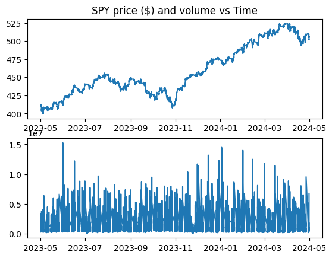

```python
# Plot price trends
fig, (ax1, ax2) = plt.subplots(2,1)

ax1.set_title("SPY price ($) and volume vs Time")
ax1.plot(new_df['timestamp'], new_df['close'])
ax2.plot(new_df['timestamp'], new_df['volume'])
```

Let's see what the mean and variance of the delta closing prices are, and what proportion is positive / negative. This will give us a little information - the MSE loss when we train the neural network to predict delta closing prices should be less than the variance in closing prices. Also, the model should perform better than random chance, so it should be at least as accurate at predicting the direction of delta closing prices than if we always picked the more probable option.

```python
print("Mean delta closing price: ", new_df['close_delta'].mean())
print("Variance of delta closing price: ", new_df['close_delta'].var())
print("Proportion of positive delta closing prices: ", (new_df['close_delta'] > 0).sum() / len(new_df))
```

```
Mean delta closing price:  0.00454836598016013
Variance of delta closing price:  0.13775913759162425
Proportion of positive delta closing prices:  0.5117578931466841
```

Let's plot 5 days worth of volume, price data, and variance vs. time. For variance, let's use a rolling window of the past 5 closing prices and take the variance of that at each step.

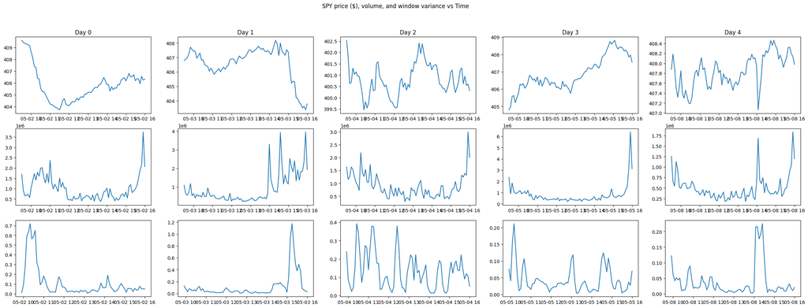

```python
# Plot price trends
cols = 5
fig, axes = plt.subplots(3, cols, figsize=(30,10))

# Get number of timesteps in a day
s = 30

fig.suptitle("SPY price ($), volume, and window variance vs Time")

# Get index of first full day
for i in range(cols):
    idx = s + i*79
    idx2 = idx+79

    axes[0, i].set_title("Day " + str(i))
    axes[0, i].plot(new_df['timestamp'][idx:idx2], new_df['close'][idx:idx2])
    axes[1, i].plot(new_df['timestamp'][idx:idx2], new_df['volume'][idx:idx2])
    axes[2, i].plot(new_df['timestamp'][idx+5:idx2], new_df['close'].rolling(5).var()[idx+5:idx2])
```

##### Checking influence of various datetime properties on distribution of close delta

Let's plot the data distribution, categorized by our various selected datetime properties, using the seaborn `violinplot`.

It seems like the time of day (in hours) affects the variance, especially at the start and end of the standard trading hours. The variance takes a U shape, starting high, then getting lowest at about noon, then increases again at the end of the day. The minutes also seem to suggest slight differences depending on the time of day. The peak at 30 minutes is likely due to people scrambling to buy/sell as soon as the regular market opens at 9:30. These data seem to be useful indicators of variance, so they could be useful for predictions in our model.

On the other hand, the distribution of the close deltas categorized by day of the week seem to have different extremes, but are otherwise similar. These differences just by looking at them seem like they could be due to random chance or significant events happening on certain days skewing the data. Ultimately, this column does not seem useful from this standpoint.

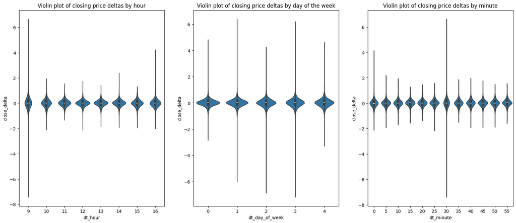

```python
fig, (ax1, ax2, ax3) = plt.subplots(1,3, figsize=(20,8))

ax1.set_title('Violin plot of closing price deltas by hour')
sns.violinplot(x='dt_hour', y='close_delta', data=new_df, ax=ax1)

ax2.set_title('Violin plot of closing price deltas by day of the week')
sns.violinplot(x='dt_day_of_week', y='close_delta', data=new_df, ax=ax2)

ax3.set_title('Violin plot of closing price deltas by minute')
sns.violinplot(x='dt_minute', y='close_delta', data=new_df, ax=ax3)
```

## Model

With the information from above, let's train a neural network to predict direction of closing price deltas using PyTorch.

We'll use a regression model to predict the `close_delta` column, and score based on accuracy (same sign). The network will take in the past n rows of data, and output a single value predicting the value of `close_delta`, and we'll use the sign of this predicted value to give us our estimated closing price delta.

Let's create a PyTorch Dataset, which is used to load data during the training process for the neural network.

```python
from torch.utils.data.dataset import Dataset
import torch

class TradingDataset(Dataset):
    def __init__(self, df: pd.DataFrame, seq_len, columns):
        self.df = df
        self.seq_len = seq_len
        self.columns = columns

        print(f'Inference model window: {seq_len}x{len(columns)} -> 1')

    def __len__(self):
        return len(self.df) - self.seq_len

    def __getitem__(self, index):
        # Get row i-n
        input  = self.df[self.columns][index: index + self.seq_len]
        output = self.df['close_delta'][index + self.seq_len]

        # Inputs, expected outputs
        # Inputs are all rows but the last, and all columns
        # Output is last row's close_delta value
        return input.to_numpy(), output
```

#### Normalizing data

Before we train the neural network, we should normalize the data. We'll drop the `df_day_of_week` column, and only use `close`, `high`, `low`, `open`, `close_delta`, `dt_hour`, `dt_minute`, `log_volume`, and the indicators, and then scale all the input columns except `close_delta`.

To do that, we can use Scikit-learn's StandardScaler to scale columns to zero mean and unit variance. Running `fit_transform` fits the scaler, storing the mean and variance for each column, and returns a new ndarray with the scaled data from the dataframe.

```python
from sklearn.preprocessing import StandardScaler

input_columns = ['close_delta', 'close', 'high', 'low', 'open', 'dt_hour', 'dt_minute', 'log_volume', 'close_sma_20', 'close_sma_50', 'close_ema_26']
scaled_columns = [ 'close', 'high', 'low', 'open', 'dt_hour', 'dt_minute', 'log_volume', 'close_sma_20', 'close_sma_50', 'close_ema_26']

scaler = StandardScaler()

data_df = new_df.copy()
data_df[scaled_columns] = scaler.fit_transform(new_df[scaled_columns])
data_df[input_columns]
```

|  | close_delta | close | high | low | open | dt_hour | dt_minute | log_volume | close_sma_20 | close_sma_50 | close_ema_26 |
| --- | --- | --- | --- | --- | --- | --- | --- | --- | --- | --- | --- |
| 0 | -0.118 | -1.334051 | -1.335749 | -1.332286 | -1.330056 | 0.373709 | 0.385234 | -1.384651 | -1.328830 | -1.338768 | -1.332631 |
| 1 | 0.084 | -1.331607 | -1.329405 | -1.327107 | -1.333548 | 0.373709 | 0.672420 | -1.381903 | -1.328371 | -1.338128 | -1.332470 |
| 2 | 0.108 | -1.328464 | -1.330685 | -1.326671 | -1.331482 | 0.373709 | 0.959606 | -1.378371 | -1.327804 | -1.337654 | -1.332088 |
| 3 | -0.110 | -1.331665 | -1.332577 | -1.325827 | -1.328164 | 0.373709 | 1.246793 | -1.381968 | -1.327338 | -1.337223 | -1.331971 |
| 4 | 0.130 | -1.327882 | -1.332722 | -1.326962 | -1.331191 | 0.373709 | 1.533979 | -1.377717 | -1.326820 | -1.336981 | -1.331582 |
| ... | ... | ... | ... | ... | ... | ... | ... | ... | ... | ... | ... |
| 19854 | -0.005 | 1.355722 | 1.358459 | 1.361723 | 1.355885 | 1.414007 | 0.672420 | 1.343517 | 1.373757 | 1.388633 | 1.375728 |
| 19855 | 0.510 | 1.370563 | 1.367190 | 1.359395 | 1.356031 | 1.414007 | 0.959606 | 1.357138 | 1.372375 | 1.387736 | 1.375512 |
| 19856 | -1.555 | 1.325313 | 1.363988 | 1.326230 | 1.370582 | 1.414007 | 1.246793 | 1.315566 | 1.368962 | 1.386149 | 1.371959 |
| 19857 | -1.465 | 1.282683 | 1.319313 | 1.289283 | 1.325909 | 1.414007 | 1.533979 | 1.276283 | 1.363592 | 1.383715 | 1.365510 |
| 19858 | 0.520 | 1.297814 | 1.331973 | 1.258445 | 1.282691 | 1.934156 | -1.625070 | 1.290239 | 1.359023 | 1.381607 | 1.360660 |

19859 rows × 11 columns

#### Model architecture

We will use a model with fully-connected layers and blocks of LSTM->Linear->ReLU with residual inputs. The architecture consists of two main classes: LSTMBlock and LSTMModel.

LSTMBlock: This class represents a single LSTM block in the network. It includes an LSTM layer, a linear layer, and a ReLU activation function. The LSTM layer is used for sequence processing, the linear layer is for transforming the output to the desired size, and the ReLU function introduces non-linearity into the model.

LSTMModel: This class represents the overall LSTM model. It includes several layers and blocks:

- Projection Input Layer (projin): This is a linear layer that transforms the input to the desired size. It's used to match the dimensionality of the input data to the hidden layer size.
- Dropout Layer: This layer is used for regularization to prevent overfitting. It randomly sets a fraction of input units to 0 at each update during training time.
- LSTM Blocks (block1, block2, block3): These are instances of the LSTMBlock class. They process the sequence data and transform the output. The use of multiple blocks can help capture complex patterns in the data.
- Residual Connections: Adding the input to each block to the output of each block before passing it into the next layer help in mitigating the vanishing gradient problem in deep networks with many layers, where networks with many layers observe smaller and smaller gradients as more layers are added.
- Squeeze Layer: This is a linear layer used to reduce the dimensionality of the output from the last LSTM block.
- Projection Output Layer (projout): This is a sequence of layers (Linear -> ReLU -> Linear) that transform the output to the desired size. The ReLU activation function introduces non-linearity, and the linear layers match the dimensionality of the output to the target size.

```python
import torch.nn as nn

class LSTMBlock(nn.Module):
    def __init__(self, size):
        super().__init__()

        self.lstm = nn.LSTM(size, size)
        self.linear = nn.Linear(size, size)
        self.relu = nn.ReLU()
        self.hx = None

    def forward(self, x):
        x, self.hx = self.lstm(x)

        x = self.linear(x)
        x = self.relu(x)
        return x


class LSTMModel(nn.Module):
    def __init__(self, seq_len, columns, out_seq_len=1, hidden_layer_size=256, dropout_rate=0.1):
        super().__init__()

        input_size = len(columns)
        output_size = out_seq_len
        size = hidden_layer_size

        self.projin = nn.Linear(input_size, size)
        self.dropout = nn.Dropout(dropout_rate)

        self.block1 = LSTMBlock(size)
        self.block2 = LSTMBlock(size)
        self.block3 = LSTMBlock(size)

        self.squeeze = nn.Linear(hidden_layer_size, 1)

        self.projout = nn.Sequential(
            nn.Linear(seq_len, seq_len),
            nn.ReLU(),
            nn.Linear(seq_len, output_size)
        )

    def forward(self, x):

        x = self.projin(x)
        x = self.dropout(x)

        res_x = x
        x = self.block1(x) + res_x

        res_x = x
        x = self.block2(x) + res_x

        res_x = x
        x = self.block3(x) + res_x
        x = self.squeeze(x).squeeze(-1)
        x = self.projout(x).squeeze(-1)

        return x
```

#### Training function

Finally, let's create the actual model. The sequence length will be set to 40, which means it will look at the past 40 intervals to predict the next closing price delta. To train the model, we'll use the mean squared error loss, which scores the output of the model based on the squared difference between the expected and output, taking the mean over the batch. The 'batch' refers to how the model is trained with multiple input-output pairs at once during each iteration. We'll use a batch size of 64. The value of this isn't too important, so you can play around with this value along with the learning rate. The optimizer we'll use is the Adam optimizer, which is one of the most commonly used optimizers for regression.

We'll also split the dataset 90/10 for training and validation, so we can see if the model can be generalized.

The `single_train` function below trains the model for a single iteration using a batch of inputs and expected outputs. In order to train, the model needs to make a prediction (forward), then calculate the loss and propagate the loss gradient backwards through the model in order to calculate the new weights (backward pass), and then finally, step the optimizer, which uses the weights from the backwards step to train the model.

```python
import torch.optim as optim
from torch.utils import data

# Train on GPU (cuda) or mac metal (mps)
device = 'mps'

# How many intervals to look back in time.
seq_len = 40

# Model, optimizer, and loss function
model = LSTMModel(40, input_columns).to(device)

loss_func = nn.MSELoss()
optimizer = optim.Adam(model.parameters(), lr=0.01)

# Validation split
valid_split = 0.1

# Split dataset randomly according to validation split
batch_size = 64
dataset = TradingDataset(data_df, seq_len, input_columns)

train_dataset, valid_dataset = data.random_split(dataset, [1-valid_split, valid_split])

train_data = data.DataLoader(train_dataset, batch_size=batch_size, shuffle=True)
valid_data = data.DataLoader(valid_dataset, batch_size=batch_size, shuffle=False)

def single_train(model, X, Y, loss_func, optimizer):
    # zero the parameter gradients
    model.zero_grad()

    # forward > backward > optimize
    y_hat   : torch.Tensor = model(X)
    loss    : torch.Tensor = loss_func.forward(y_hat, Y)

    loss.backward()
    optimizer.step()

    return y_hat, loss


def single_infer(model, X, Y, loss_func):
    # forward
    y_hat   : torch.Tensor = model(X)
    loss    : torch.Tensor = loss_func.forward(y_hat, Y)

    return y_hat, loss
```

```
Inference model window: 40x11 -> 1
```

#### Training loop

```python
epochs = 15

def format_acc(acc):
    return str(int(acc*100))+"%"

losses = []
accs = []
valid_losses = []
valid_accs = []

for e in range(epochs):
    print(f"Epoch {e+1}/{epochs}")

    train_loss = 0
    train_acc = 0
    train_progress = tqdm(train_data)

    model.train(False)
    for it, data in enumerate(train_progress):
        X, Y = data
        X, Y = X.float().to(device), Y.float().to(device)
        y_hat, loss = single_train(model, X, Y, loss_func, optimizer)

        train_loss += loss.mean().item()
        train_acc += torch.sign(y_hat*Y > 0).sum().item() / y_hat.numel()

        # Display avg loss over epoch on progress bar
        loss = train_loss / (it + 1)
        acc = train_acc / (it + 1)
        train_progress.set_postfix({"loss": loss, "acc":format_acc(acc)}, refresh=False)

    losses.append(loss)
    accs.append(acc)

    valid_loss = 0
    valid_acc = 0
    valid_progress = tqdm(valid_data)

    model.train(False)
    for it, data in enumerate(valid_progress):
        X, Y = data
        X, Y = X.float().to(device), Y.float().to(device)

        y_hat, loss = single_train(model, X, Y, loss_func, optimizer)

        valid_loss += loss.mean().item()
        valid_acc += torch.sign(y_hat*Y > 0).sum().item() / y_hat.numel()

        # Display avg loss over epoch on progress bar
        loss = valid_loss / (it + 1)
        acc = valid_acc / (it + 1)
        valid_progress.set_postfix({"loss": loss, "acc":format_acc(acc)}, refresh=False)

    valid_losses.append(loss)
    valid_accs.append(acc)
```

```
Mean delta closing price:  0.00454836598016013
Variance of delta closing price:  0.13775913759162425
Proportion of positive delta closing prices:  0.5117578931466841
```

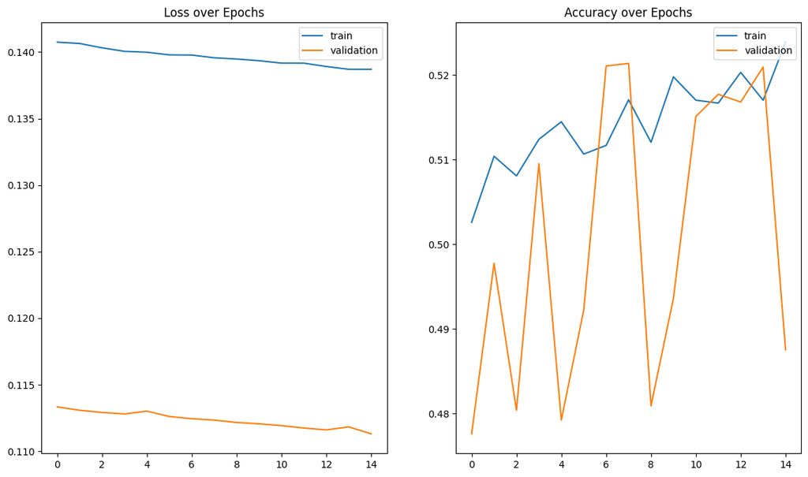

```python
print("Mean delta closing price: ", new_df['close_delta'].mean())
print("Variance of delta closing price: ", new_df['close_delta'].var())
print("Proportion of positive delta closing prices: ", (new_df['close_delta'] > 0).sum() / len(new_df))

fig, axs = plt.subplots(1,2, figsize=(14,8))

axs[0].plot(losses, label="train")
axs[0].plot(valid_losses, label="validation")
axs[0].legend(loc="upper right")
axs[0].set_title("Loss over Epochs")

axs[1].plot(accs, label="train")
axs[1].plot(valid_accs, label="validation")
axs[1].legend(loc="upper right")
axs[1].set_title("Accuracy over Epochs")
```